# 社交媒体使用对生产力影响的分析报告

**数据来源：**https://www.kaggle.com/datasets/asifxzaman/social-media-addiction-vs-productivity-dataset  
**GitHub仓库：**https://github.com/MM5412-Hachimi-Group/MM5412-Group-Project-Alternative

## 项目概述

本报告分析社交媒体使用习惯如何影响个人生产力，并构建机器学习模型来预测生产力得分和成瘾程度分类。

### 数据集说明

- **数据来源**: MM5412 小组项目数据
- **样本量**: 6000 条记录
- **特征变量**: 9 个

| 变量名 | 说明 | 类型 |
| --- | --- | --- |
| age | 年龄 | 数值 |
| daily_screen_time | 每日屏幕使用时间（小时） | 数值 |
| social_media_hours | 每日社交媒体使用时间（小时） | 数值 |
| study_hours | 每日学习时间（小时） | 数值 |
| sleep_hours | 每日睡眠时间（小时） | 数值 |
| notifications_per_day | 每日通知数量 | 数值 |
| focus_score | 专注力得分 | 数值 |
| addiction_level | 成瘾程度 | 分类（低/中/高） |
| productivity_score | 生产力得分 | 数值 |

### 分析目标

1. **描述性分析**: 了解数据基本特征和分布
2. **探索性分析(EDA)**: 发现变量间的关系和模式
3. **相关性分析**: 分析各变量与生产力的相关性
4. **回归分析**: 构建模型预测生产力得分
5. **分类分析**: 构建模型预测成瘾程度

### 输出目录

- `./Image/`: 可视化图表
- `./Model/`: 机器学习模型
- `./Describe/`: 描述性统计结果

```python
# 导入必要的库
import pandas as pd
import numpy as np
import matplotlib.pyplot as plt
import seaborn as sns
import warnings
import os
import sys
import platform

# 设置显示选项
warnings.filterwarnings('ignore')
pd.set_option('display.max_columns', None)
pd.set_option('display.width', None)

# ========== 字体设置 ==========
from matplotlib import font_manager as fm

# 查找系统中可用的中文字体
def find_chinese_font():
    """查找系统中可用的中文字体"""
    fonts = fm.fontManager.ttflist
    font_names = ['STHeiti', 'PingFang', 'Hiragino', 'Lantinghei', 'Weibei']
    for name in font_names:
        for f in fonts:
            if name in f.name:
                return f.fname
    return None

# 加载中文字体
CHINESE_FONT_PATH = find_chinese_font()
if CHINESE_FONT_PATH:
    fm.fontManager.addfont(CHINESE_FONT_PATH)
    CHINESE_FONT = fm.FontProperties(fname=CHINESE_FONT_PATH)
    print(f'已加载中文字体: {CHINESE_FONT_PATH}')
else:
    CHINESE_FONT = None
    print('未找到中文字体，将使用英文标签')

plt.rcParams['axes.unicode_minus'] = False

def get_font(size=10):
    """获取中文字体属性"""
    if CHINESE_FONT:
        return CHINESE_FONT.copy()
    return None

print('字体设置完成')

# 创建输出目录
image_dir = './Image/'
model_dir = './Model/'
describe_dir = './Describe/'
os.makedirs(image_dir, exist_ok=True)
os.makedirs(model_dir, exist_ok=True)
os.makedirs(describe_dir, exist_ok=True)

print('目录创建完成')
```

```
已加载中文字体: /System/Library/AssetsV2/com_apple_MobileAsset_Font8/53fe5be564086fefc7523ccd0a31200acf92e0e5.asset/AssetData/STHEITI.ttf
字体设置完成
目录创建完成
```

```python
# 读取数据
data_path = './Data/social_media_productivity_6000.csv'
df = pd.read_csv(data_path)

# 查看数据基本信息
print("=" * 60)
print("数据集基本信息")
print("=" * 60)
print(f"\n数据集形状: {df.shape[0]} 行 × {df.shape[1]} 列")
print(f"\n列名: {list(df.columns)}")
print("\n" + "=" * 60)
print("前10行数据预览")
print("=" * 60)
df.head(10)
```

```
============================================================
数据集基本信息
============================================================

数据集形状: 6000 行 × 9 列

列名: ['age', 'daily_screen_time', 'social_media_hours', 'study_hours', 'sleep_hours', 'notifications_per_day', 'focus_score', 'addiction_level', 'productivity_score']

============================================================
前10行数据预览
============================================================
```

|  | age | daily_screen_time | social_media_hours | study_hours | sleep_hours | notifications_per_day | focus_score | addiction_level | productivity_score |
| --- | --- | --- | --- | --- | --- | --- | --- | --- | --- |
| 0 | 21.0 | 5.95 | 2.81 | 2.61 | 6.99 | 283.0 | 100.00 | Medium | 28.49 |
| 1 | 34.0 | 3.82 | 2.33 | 0.28 | 7.47 | 266.0 | 93.65 | Medium | 18.54 |
| 2 | 29.0 | 3.57 | 1.64 | 5.21 | 6.34 | 137.0 | 100.00 | Low | 68.52 |
| 3 | 25.0 | 10.27 | 4.37 | 4.28 | 4.49 | 247.0 | 94.71 | Medium | 27.82 |
| 4 | 22.0 | 2.42 | 1.60 | 3.67 | 6.34 | 28.0 | 100.00 | Low | 51.09 |
| 5 | 35.0 | 6.19 | 2.19 | 7.26 | 4.41 | 218.0 | 100.00 | Medium | 67.38 |
| 6 | 21.0 | 3.68 | 1.23 | 1.34 | 7.41 | 296.0 | 100.00 | Low | 37.22 |
| 7 | 33.0 | 10.79 | 5.65 | 0.08 | 7.95 | 148.0 | 83.64 | High | 0.00 |
| 8 | 37.0 | 7.57 | 5.54 | 0.59 | 8.81 | 81.0 | 94.43 | High | 0.00 |
| 9 | 25.0 | 4.31 | 2.73 | 1.79 | 4.74 | 21.0 | 100.00 | Medium | 41.86 |

### 1.1 数据类型和缺失值检查

```python
# 查看数据类型
print("=" * 60)
print("数据类型信息")
print("=" * 60)
print(df.dtypes)

# 缺失值分析
print("\n" + "=" * 60)
print("缺失值统计")
print("=" * 60)
missing_info = pd.DataFrame({
    '缺失数量': df.isnull().sum(),
    '缺失比例(%)': (df.isnull().sum() / len(df) * 100).round(2)
})
print(missing_info[missing_info['缺失数量'] > 0])

# 总体缺失率
total_missing = df.isnull().sum().sum()
total_cells = df.shape[0] * df.shape[1]
print(f"\n总体缺失率: {total_missing/total_cells*100:.2f}%")
```

```
============================================================
数据类型信息
============================================================
age                      float64
daily_screen_time        float64
social_media_hours       float64
study_hours              float64
sleep_hours              float64
notifications_per_day    float64
focus_score              float64
addiction_level           object
productivity_score       float64
dtype: object

============================================================
缺失值统计
============================================================
                       缺失数量  缺失比例(%)
age                     120      2.0
daily_screen_time       120      2.0
social_media_hours      120      2.0
study_hours             120      2.0
sleep_hours             120      2.0
notifications_per_day   120      2.0
focus_score             120      2.0
addiction_level         120      2.0
productivity_score      120      2.0

总体缺失率: 2.00%
```

### 1.2 数据清洗

```python
# 复制数据用于清洗
df_clean = df.copy()

# 1. 数值型缺失值 - 使用该列均值填充
numeric_cols = ['age', 'daily_screen_time', 'social_media_hours', 'study_hours',
                'sleep_hours', 'notifications_per_day', 'focus_score', 'productivity_score']
for col in numeric_cols:
    if df_clean[col].isnull().sum() > 0:
        df_clean[col].fillna(df_clean[col].mean(), inplace=True)

# 2. 分类型缺失值 - 使用众数填充
addiction_mode = df_clean['addiction_level'].mode()[0]
df_clean['addiction_level'].fillna(addiction_mode, inplace=True)

# 3. 检查并处理异常值
print("=" * 60)
print("异常值检测（使用IQR方法）")
print("=" * 60)

outlier_info = {}
for col in numeric_cols:
    Q1 = df_clean[col].quantile(0.25)
    Q3 = df_clean[col].quantile(0.75)
    IQR = Q3 - Q1
    lower_bound = Q1 - 1.5 * IQR
    upper_bound = Q3 + 1.5 * IQR
    outliers = ((df_clean[col] < lower_bound) | (df_clean[col] > upper_bound)).sum()
    outlier_info[col] = {
        'outliers': outliers,
        'percent': outliers/len(df_clean)*100,
        'lower_bound': lower_bound,
        'upper_bound': upper_bound
    }
    print(f"{col}: {outliers} 个异常值 ({outliers/len(df_clean)*100:.2f}%)")

# 3. 验证清洗后的数据
print("\n" + "=" * 60)
print("数据清洗后验证")
print("=" * 60)
print(f"缺失值总数: {df_clean.isnull().sum().sum()}")
print(f"数据集形状: {df_clean.shape}")
```

```
============================================================
异常值检测（使用IQR方法）
============================================================
age: 0 个异常值 (0.00%)
daily_screen_time: 0 个异常值 (0.00%)
social_media_hours: 34 个异常值 (0.57%)
study_hours: 0 个异常值 (0.00%)
sleep_hours: 0 个异常值 (0.00%)
notifications_per_day: 0 个异常值 (0.00%)
focus_score: 932 个异常值 (15.53%)
productivity_score: 0 个异常值 (0.00%)

============================================================
数据清洗后验证
============================================================
缺失值总数: 0
数据集形状: (6000, 9)
```

## 2. 描述性统计分析

```python
# 数值型变量描述性统计
print("=" * 60)
print("数值型变量描述性统计")
print("=" * 60)
desc_stats = df_clean[numeric_cols].describe().round(2)
print(desc_stats)

# 保存描述性统计到CSV
desc_stats.to_csv(f'{describe_dir}descriptive_statistics.csv', encoding='utf-8-sig')
print("\n描述性统计已保存至: " + describe_dir + "descriptive_statistics.csv")
```

```
============================================================
数值型变量描述性统计
============================================================
           age  daily_screen_time  social_media_hours  study_hours  \
count  6000.00            6000.00             6000.00      6000.00
mean     27.11               6.92                4.15         4.07
std       7.20               2.83                2.13         2.29
min      15.00               2.00                0.66         0.00
25%      21.00               4.52                2.43         2.16
50%      27.00               6.92                3.82         4.07
75%      33.00               9.31                5.49         6.00
max      39.00              11.99               10.66         8.00

       sleep_hours  notifications_per_day  focus_score  productivity_score
count      6000.00                6000.00      6000.00             6000.00
mean          6.51                 159.78        96.36               37.61
std           1.42                  80.23         7.34               27.33
min           4.00                  20.00        47.39                0.00
25%           5.30                  90.00        96.36               14.31
50%           6.51                 159.78       100.00               37.10
75%           7.70                 230.00       100.00               58.14
max           9.00                 299.00       100.00              100.00

描述性统计已保存至: ./Describe/descriptive_statistics.csv
```

```python
# 分类型变量统计
print("=" * 60)
print("分类型变量统计")
print("=" * 60)

cat_col = 'addiction_level'
print(f"\n{cat_col} 分布:")
cat_stats = df_clean[cat_col].value_counts()
cat_pct = df_clean[cat_col].value_counts(normalize=True) * 100
cat_df = pd.DataFrame({
    '数量': cat_stats,
    '比例(%)': cat_pct.round(2)
})
print(cat_df)
```

```
============================================================
分类型变量统计
============================================================

addiction_level 分布:
                   数量  比例(%)
addiction_level
Medium           3184  53.07
High             1857  30.95
Low               959  15.98
```

## 3. 探索性数据分析 (EDA)

### 3.1 数值变量分布直方图

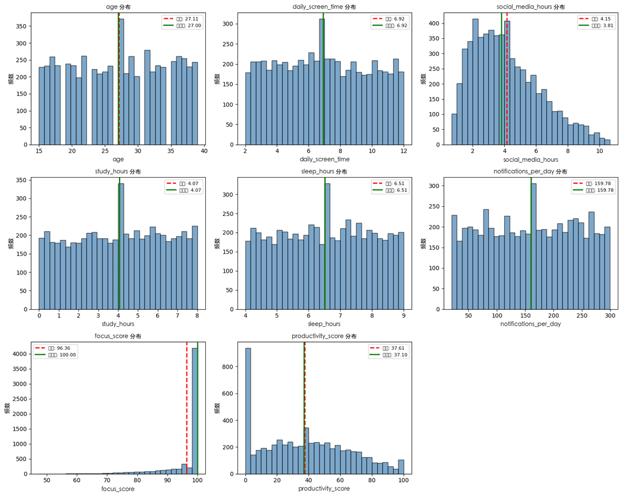

```
图片已保存至: ./Image/01_numeric_distribution.png
```

```python
# 3.1 数值变量分布直方图
fig, axes = plt.subplots(3, 3, figsize=(15, 12))
axes = axes.flatten()

for idx, col in enumerate(numeric_cols):
    ax = axes[idx]
    ax.hist(df_clean[col], bins=30, edgecolor='black', alpha=0.7, color='steelblue')
    ax.set_title(f'{col} 分布', fontsize=12, fontweight='bold', fontproperties=get_font())
    ax.set_xlabel(col, fontproperties=get_font())
    ax.set_ylabel('频数', fontproperties=get_font())

    # 添加均值和中位数线
    mean_val = df_clean[col].mean()
    median_val = df_clean[col].median()
    ax.axvline(mean_val, color='red', linestyle='--', linewidth=2, label=f'均值: {mean_val:.2f}')
    ax.axvline(median_val, color='green', linestyle='-', linewidth=2, label=f'中位数: {median_val:.2f}')
    ax.legend(fontsize=8)

# 隐藏多余的子图
for idx in range(len(numeric_cols), len(axes)):
    axes[idx].set_visible(False)

plt.tight_layout()
plt.savefig(f'{image_dir}01_numeric_distribution.png', dpi=150, bbox_inches='tight')
plt.show()
print(f"图片已保存至: {image_dir}01_numeric_distribution.png")
```

### 数值变量分布解读

**图表说明**: 展示所有数值变量的分布直方图，红线表示均值，绿线表示中位数。

### 3.2 成瘾程度分布可视化

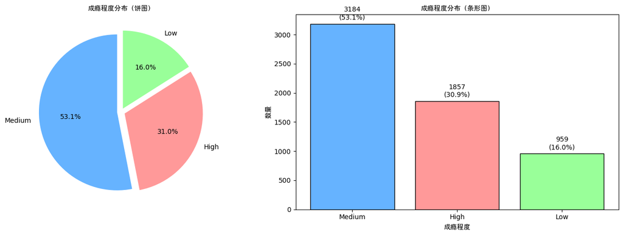

```
图片已保存至: ./Image/02_addiction_distribution.png
```

```python
# 3.2 成瘾程度分布可视化
fig, axes = plt.subplots(1, 2, figsize=(14, 5))

# 饼图
colors = ['#66b3ff', '#ff9999', '#99ff99']
addiction_counts = df_clean['addiction_level'].value_counts()
axes[0].pie(addiction_counts, labels=addiction_counts.index, autopct='%1.1f%%',
            colors=colors, explode=(0.05, 0.05, 0.05), startangle=90)
axes[0].set_title('成瘾程度分布（饼图）', fontsize=14, fontweight='bold', fontproperties=get_font())

# 条形图
bars = axes[1].bar(addiction_counts.index, addiction_counts.values, color=colors, edgecolor='black')
axes[1].set_title('成瘾程度分布（条形图）', fontsize=14, fontweight='bold', fontproperties=get_font())
axes[1].set_xlabel('成瘾程度', fontproperties=get_font())
axes[1].set_ylabel('数量', fontproperties=get_font())

# 添加数值标签
for bar, count in zip(bars, addiction_counts.values):
    axes[1].text(bar.get_x() + bar.get_width()/2, bar.get_height() + 50,
                f'{count}\n({count/len(df_clean)*100:.1f}%)',
                ha='center', va='bottom', fontsize=10)

plt.tight_layout()
plt.savefig(f'{image_dir}02_addiction_distribution.png', dpi=150, bbox_inches='tight')
plt.show()
print(f"图片已保存至: {image_dir}02_addiction_distribution.png")
```

### 成瘾程度分布解读

**图表说明**: 展示成瘾程度的分布情况。

### 3.3 相关性分析

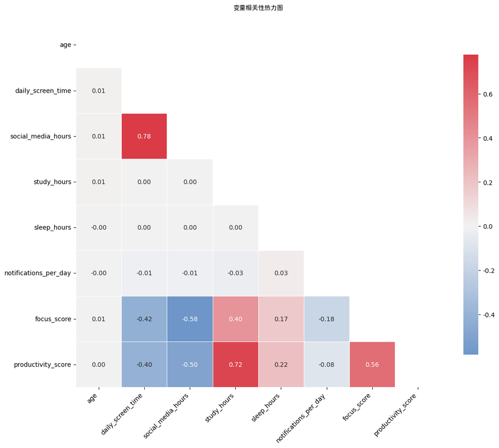

```
图片已保存至: ./Image/03_correlation_heatmap.png
```

```python
# 3.3 相关性分析
# 计算相关系数矩阵
corr_matrix = df_clean[numeric_cols].corr()

# 绘制热力图
fig, ax = plt.subplots(figsize=(12, 10))
mask = np.triu(np.ones_like(corr_matrix, dtype=bool))
cmap = sns.diverging_palette(250, 10, as_cmap=True)

sns.heatmap(corr_matrix, mask=mask, cmap=cmap, center=0,
            annot=True, fmt='.2f', square=True, linewidths=0.5,
            cbar_kws={"shrink": 0.8})
plt.title('变量相关性热力图', fontsize=16, fontweight='bold', pad=20, fontproperties=get_font())
plt.xticks(rotation=45, ha='right')
plt.tight_layout()
plt.savefig(f'{image_dir}03_correlation_heatmap.png', dpi=150, bbox_inches='tight')
plt.show()
print(f"图片已保存至: {image_dir}03_correlation_heatmap.png")
```

### 相关性分析解读

**图表说明**: 展示各数值变量之间的Pearson相关系数。

**业务洞察**: 提高生产力的关键因素是增加学习时间和专注力，减少社交媒体使用和屏幕时间

### 3.4 关键变量与生产力的关系散点图

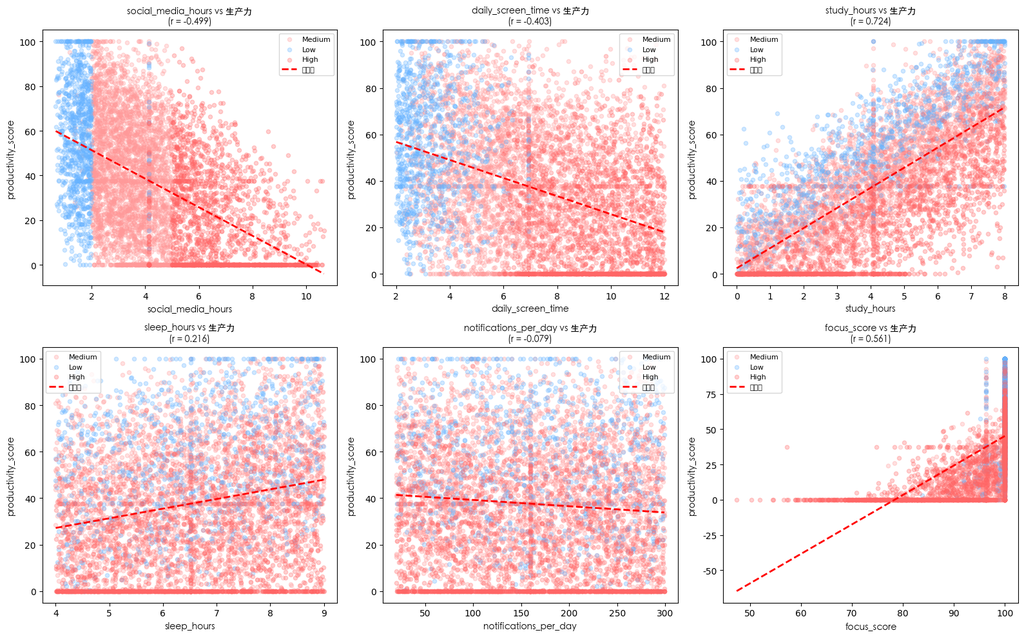

```
图片已保存至: ./Image/04_scatter_analysis.png
```

```python
# 3.4 关键变量与生产力的关系散点图
fig, axes = plt.subplots(2, 3, figsize=(16, 10))

key_vars = ['social_media_hours', 'daily_screen_time', 'study_hours',
            'sleep_hours', 'notifications_per_day', 'focus_score']

for idx, var in enumerate(key_vars):
    ax = axes[idx // 3, idx % 3]

    # 根据成瘾程度着色
    colors_map = {'Low': '#66b3ff', 'Medium': '#ff9999', 'High': '#ff6666'}
    for level in df_clean['addiction_level'].unique():
        subset = df_clean[df_clean['addiction_level'] == level]
        ax.scatter(subset[var], subset['productivity_score'],
                  alpha=0.3, label=level, c=colors_map.get(level, 'gray'), s=20)

    # 添加趋势线
    z = np.polyfit(df_clean[var], df_clean['productivity_score'], 1)
    p = np.poly1d(z)
    x_line = np.linspace(df_clean[var].min(), df_clean[var].max(), 100)
    ax.plot(x_line, p(x_line), 'r--', linewidth=2, label='趋势线')

    corr = df_clean[var].corr(df_clean['productivity_score'])
    ax.set_title(f'{var} vs 生产力\n(r = {corr:.3f})', fontsize=11, fontweight='bold', fontproperties=get_font())
    ax.set_xlabel(var, fontproperties=get_font())
    ax.set_ylabel('productivity_score', fontproperties=get_font())
    ax.legend(fontsize=8)

plt.tight_layout()
plt.savefig(f'{image_dir}04_scatter_analysis.png', dpi=150, bbox_inches='tight')
plt.show()
print(f"图片已保存至: {image_dir}04_scatter_analysis.png")
```

### 关键变量与生产力关系解读

**图表说明**: 展示6个关键自变量与生产力得分的散点图，按成瘾程度着色。

**关键发现**:

1. **社交媒体时间**: 明显负向趋势，高成瘾者（红色点）集中在低生产力区域
2. **屏幕时间**: 负向趋势，中高成瘾者生产力普遍较低
3. **学习时间**: 明显正向趋势，学习时间越长生产力越高
4. **睡眠时间**: 轻微正向趋势，睡眠充足者生产力略高
5. **通知数量**: 轻微负向趋势
6. **专注力得分**: 强正向趋势，专注力越高生产力越高

**核心结论**: 社交媒体使用是生产力的重要负面因素，而学习时间和专注力是最重要的正向预测因子

### 3.5 不同成瘾程度的特征对比

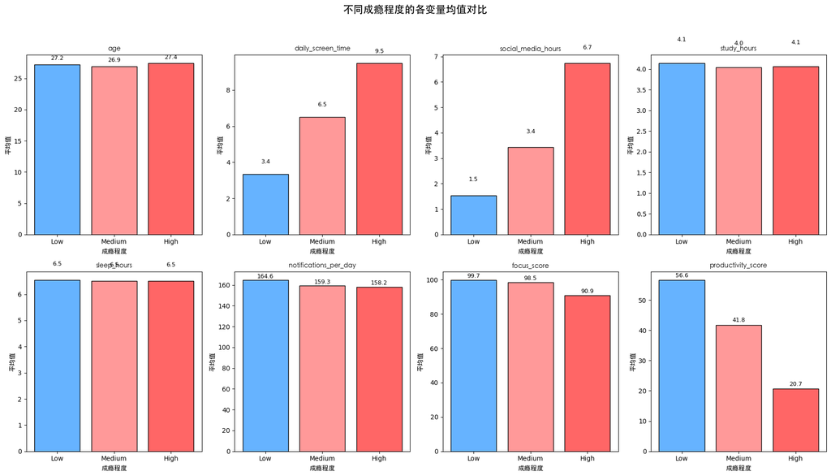

```
图片已保存至: ./Image/05_addiction_comparison.png
```

```python
# 3.5 不同成瘾程度的特征对比
fig, axes = plt.subplots(2, 4, figsize=(18, 10))
axes = axes.flatten()

# 按成瘾程度分组统计
grouped = df_clean.groupby('addiction_level')[numeric_cols].mean()

colors = ['#66b3ff', '#ff9999', '#ff6666']
level_order = ['Low', 'Medium', 'High']

for idx, col in enumerate(numeric_cols):
    ax = axes[idx]
    values = [grouped.loc[level, col] for level in level_order]
    bars = ax.bar(level_order, values, color=colors, edgecolor='black')
    ax.set_title(f'{col}', fontsize=12, fontweight='bold', fontproperties=get_font())
    ax.set_xlabel('成瘾程度', fontproperties=get_font())
    ax.set_ylabel('平均值', fontproperties=get_font())

    # 添加数值标签
    for bar, val in zip(bars, values):
        ax.text(bar.get_x() + bar.get_width()/2, bar.get_height() + 0.5,
                f'{val:.1f}', ha='center', va='bottom', fontsize=9)

plt.suptitle('不同成瘾程度的各变量均值对比', fontsize=16, fontweight='bold', y=1.02, fontproperties=get_font())
plt.tight_layout()
plt.savefig(f'{image_dir}05_addiction_comparison.png', dpi=150, bbox_inches='tight')
plt.show()
print(f"图片已保存至: {image_dir}05_addiction_comparison.png")
```

### 成瘾程度特征对比解读

**图表说明**: 对比不同成瘾程度群体在各变量上的平均值差异。

[output not shown]

### 3.6 社交媒体使用与生产力的箱线图分析

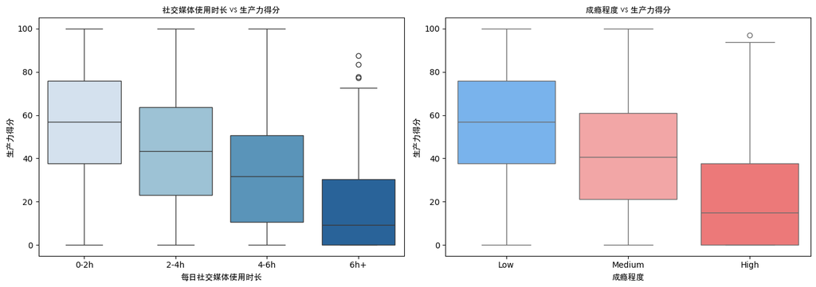

```
图片已保存至: ./Image/06_boxplot_analysis.png
```

```python
# 3.6 社交媒体使用与生产力的箱线图分析
fig, axes = plt.subplots(1, 2, figsize=(14, 5))

# 按社交媒体使用时长分组
df_clean['social_media_group'] = pd.cut(df_clean['social_media_hours'],
                                         bins=[0, 2, 4, 6, 10],
                                         labels=['0-2h', '2-4h', '4-6h', '6h+'])

# 箱线图1: 社交媒体时长 vs 生产力
sns.boxplot(x='social_media_group', y='productivity_score', data=df_clean, ax=axes[0], palette='Blues')
axes[0].set_title('社交媒体使用时长 vs 生产力得分', fontsize=12, fontweight='bold', fontproperties=get_font())
axes[0].set_xlabel('每日社交媒体使用时长', fontproperties=get_font())
axes[0].set_ylabel('生产力得分', fontproperties=get_font())

# 箱线图2: 成瘾程度 vs 生产力
sns.boxplot(x='addiction_level', y='productivity_score', data=df_clean,
            ax=axes[1], palette=['#66b3ff', '#ff9999', '#ff6666'], order=['Low', 'Medium', 'High'])
axes[1].set_title('成瘾程度 vs 生产力得分', fontsize=12, fontweight='bold', fontproperties=get_font())
axes[1].set_xlabel('成瘾程度', fontproperties=get_font())
axes[1].set_ylabel('生产力得分', fontproperties=get_font())

plt.tight_layout()
plt.savefig(f'{image_dir}06_boxplot_analysis.png', dpi=150, bbox_inches='tight')
plt.show()
print(f"图片已保存至: {image_dir}06_boxplot_analysis.png")
```